# LC2P: Fixed effects only linear and logistic regression

Laurel Brehm

# Linear regression

Let’s think statistically about some of the relationships in the lexdec set.

For example, consider again: how does RT vary by word frequency? We looked at that with a correlation and a t-test, but there’s another important relationship: that of the best-fit line that describes the points.

Lines are regression models. Regressions are the #1 tool to learn for describing data. We will talk about a variety of types of regression models today.

Start again with a plot: the overall relationship between RT and word frequency.

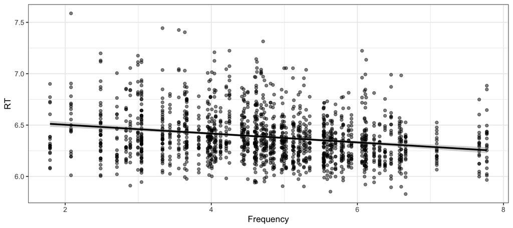

```r
ggplot(lexdec,aes(x=Frequency,y=RT))+
  geom_point(alpha=.5)+
   geom_smooth(method='lm',color='black')+
  theme_bw()
```

# Linear regression with a continuous predictor

One model we could run on the data in this plot is a linear regression on RT, using the continuous predictor (also called ‘fixed effect’) of ‘frequency’. Regression is the degree to which some dependent variable y is predicted by some independent variable (predictor, also called ‘fixed effect’) x.

We can get parameters for the slope and intercept– and the ratio of their estimate to error (a t-value!)– by running the following code…

Importantly, because we care about the intercept, this test is not symmetric– the Y variable (= dependent variable) always goes to the left. (Note how this differs from the correlation case we ran yesterday– we’re drawing lines, rather than characterising covariance.)

```r
lm1 <- lm(RT~Frequency, data=lexdec)
summary(lm1)
```

```
##
## Call:
## lm(formula = RT ~ Frequency, data = lexdec)
##
## Residuals:
##      Min       1Q   Median       3Q      Max
## -0.55407 -0.16153 -0.03494  0.11699  1.08768
##
## Coefficients:
##              Estimate Std. Error t value Pr(>|t|)
## (Intercept)  6.588778   0.022296 295.515   <2e-16 ***
## Frequency   -0.042872   0.004533  -9.459   <2e-16 ***
## ---
## Signif. codes:  0 '***' 0.001 '**' 0.01 '*' 0.05 '.' 0.1 ' ' 1
##
## Residual standard error: 0.2353 on 1657 degrees of freedom
## Multiple R-squared:  0.05123,    Adjusted R-squared:  0.05066
## F-statistic: 89.47 on 1 and 1657 DF,  p-value: < 2.2e-16
```

# Residuals

We can run some code to save the residual errors from a model and then make plots of those too.

# Residuals

Three things to check in these plots:

(1). Are the residuals co-varying with the Y value (going up or down, rather than straight across)? This would mean we haven’t explaned some part of Y very well. (Looks like that’s the case here… a lot else going on other than frequency)

(2). Are the residuals normally distributed (following a bell curve centered at zero)? Approximately– that’s good. That’s the main condition for whether the data *should* be fitted with a standard linear regression model.

(3). Do the residuals follow the same distribution as the original data?– do they make a line if we plot the quantiles of each against each other? This is another diagnostic for whether the data *should* be fitted with a standard linear model.

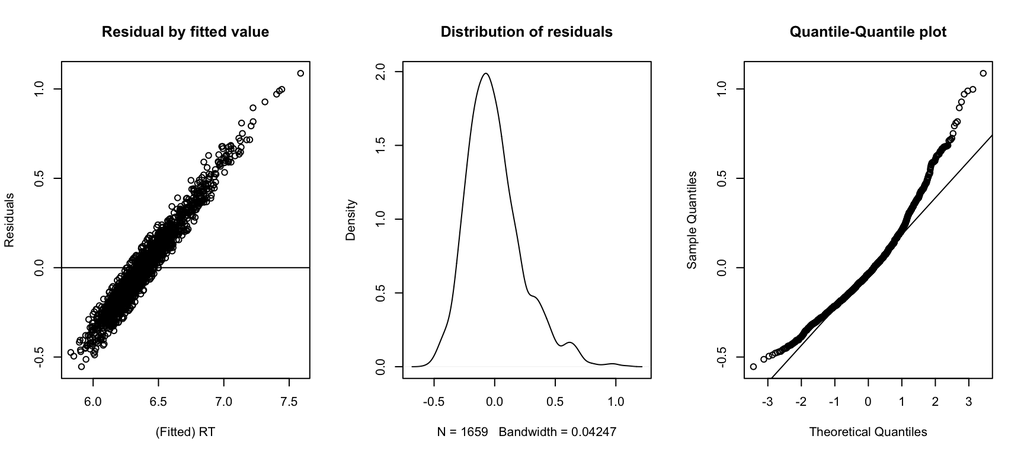

```r
Lm1Residuals <- resid(lm1)

## the code below uses base R plots:
par(mfrow=c(1,3)) ## for base R plots: putting all in a row

plot(lexdec$RT,Lm1Residuals,main='Residual by fitted value',
     ylab='Residuals',xlab='(Fitted) RT'); abline(0,0)

plot(density(Lm1Residuals),main='Distribution of residuals')

qqnorm(Lm1Residuals, main="Quantile-Quantile plot");
    qqline(resid(lm1))
```

# Linear regression with categorical predictors

It’s simple to run a linear regression with categorical predictors too. This means you can test a lot of questions with a regression *instead of a t-test!* – and in fact, it also means that a t-test is a special case of a regression model.

To draw a line (= run a regression) with categorical predictors, you need to assign x values to things that are not numbers. This is called setting contrasts.

Let’s walk through what this means in terms of the ‘NativeLanguage’ predictor in lexdec.

Here’s a plot. I made it as points only with error bars because R won’t draw a line between “English” and “Other”.

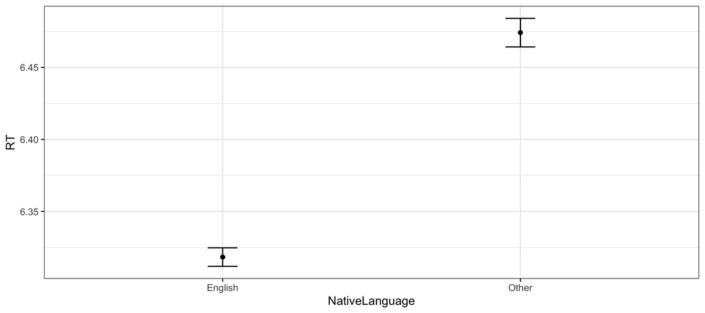

```r
ggplot(lexdec,aes(x=NativeLanguage, y=RT))+
    stat_summary(fun.y = mean, geom = "point") +
    stat_summary(fun.data = mean_se, geom = "errorbar",width=.1)+
    theme_bw()
```

# Linear regression with categorical predictors

To draw a line, *all we have to do is code these values as numbers*. This is *exactly* what constrast coding is.

Here is one way of turning “NativeLanguage” to a number– I told R to I set the first-in-the-alphabet value (“English”) to 0, and the second (“Other”) to 1 with the code ‘as.numeric(FACTOR)-1’.

Now we can plot this as a line (using some extra code for setting the scale prettily.) I also marked the intercept value in the graph– Y where X=0 – note that it corresponds to the “English” outcome.

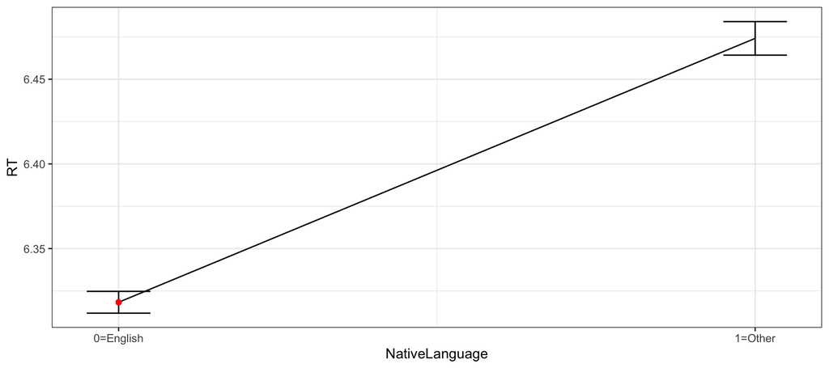

```r
im <- unlist(lexdec %>% filter(NativeLanguage=='English')
             %>% summarise(mean(RT)))

ggplot(lexdec,aes(x=as.numeric(NativeLanguage)-1, y=RT))+
    stat_summary(fun.y = mean, geom = "line") +
    stat_summary(fun.data = mean_se, geom = "errorbar",width=.1)+
    theme_bw()+
    scale_x_continuous("NativeLanguage",breaks=c(0,1),
                       labels=c("0=English", "1=Other"))+
    geom_point(aes(x=0,y=im),color='red')
```

# Linear regression with categorical predictors: dummy coding

This way of contrast coding the factor (categorical predictor) ‘NativeLanguage’ is what R does by default. You can check what numbers R has assigned to a factor by running this line of code: contrasts(FACTOR)

We can then run a linear model just like we would for a continuous predictor!

In the model below, the intercept represents RT when X=0…aka, the effect of being in the ‘English’ group. (Same as the red dot in the plot above.)

The next variable (the fixed effect) is then the effect of being in the ‘Other’ group: an RT that is .15 log milliseconds more. This is a reliable difference– as noted by the t-value (ratio of estimate to error) and p-value associated with it.

(And as a short aside– if you go back and look at the code we ran yesterday, you’ll note that the t-test on these data gave the same answer… because it’s secretly the same test)

```r
contrasts(lexdec$NativeLanguage)
```

```
##         Other
## English     0
## Other       1
```

```r
lm2 <- lm(RT~NativeLanguage, data=lexdec)
summary(lm2)
```

```
##
## Call:
## lm(formula = RT ~ NativeLanguage, data = lexdec)
##
## Residuals:
##      Min       1Q   Median       3Q      Max
## -0.56877 -0.15289 -0.03231  0.11480  1.11318
##
## Coefficients:
##                     Estimate Std. Error t value Pr(>|t|)
## (Intercept)         6.318309   0.007435  849.78   <2e-16 ***
## NativeLanguageOther 0.155821   0.011358   13.72   <2e-16 ***
## ---
## Signif. codes:  0 '***' 0.001 '**' 0.01 '*' 0.05 '.' 0.1 ' ' 1
##
## Residual standard error: 0.2289 on 1657 degrees of freedom
## Multiple R-squared:  0.102,  Adjusted R-squared:  0.1015
## F-statistic: 188.2 on 1 and 1657 DF,  p-value: < 2.2e-16
```

# Linear regression with categorical predictors: effects coding

We can also *set* our contrasts. Here is another option: If we put the intercept in the *middle* of our levels (shown in the plot below), this will make the intercept reflect the *mean of the conditions*. This means that the fixed effect in the model will properly be the *main effect* of NativeLanguage.

Here, using the contrasts of (-1,1) means that the main effect represents the difference between each level (one unit step in each direction) and the grand mean (zero).

[Think: What would contrasts of (-.5, .5) therefore represent?]

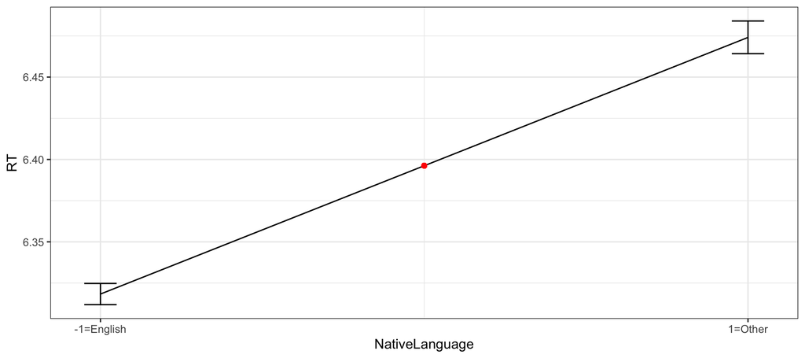

```r
contrasts(lexdec$NativeLanguage) = c(-1, 1)

lm3 <- lm(RT~NativeLanguage, data=lexdec)
summary(lm3)
```

```
##
## Call:
## lm(formula = RT ~ NativeLanguage, data = lexdec)
##
## Residuals:
##      Min       1Q   Median       3Q      Max
## -0.56877 -0.15289 -0.03231  0.11480  1.11318
##
## Coefficients:
##                 Estimate Std. Error t value Pr(>|t|)
## (Intercept)     6.396220   0.005679 1126.34   <2e-16 ***
## NativeLanguage1 0.077911   0.005679   13.72   <2e-16 ***
## ---
## Signif. codes:  0 '***' 0.001 '**' 0.01 '*' 0.05 '.' 0.1 ' ' 1
##
## Residual standard error: 0.2289 on 1657 degrees of freedom
## Multiple R-squared:  0.102,  Adjusted R-squared:  0.1015
## F-statistic: 188.2 on 1 and 1657 DF,  p-value: < 2.2e-16
```

# Logistic regression: to a generalized line

We can generalize our line even more– in fact, we aren’t restricted to linear outcome variables either. The equations that implement linear regression have been generalized to other dependant measures to make *GLM*s – generalized linear models.

# Walk-through of an example: Titanic

It is very simple to implement a logistic regression model in R. It is somewhat less simple to understand what the model means. Let’s unpack both together.

We’ll start with a simple logistic regression example using Titanic survivorship data. People either survived (a success, coded as 1), or they did not. This is a very clear example of a binomial outcome.

Start by reading in the data, re-coding one variable appropriately, and creating a table that shows how many people survived.

```r
TitanicAll <- read.csv('TitanicAll.csv',header=T, sep="\t")

TitanicAll$Pclass <- as.factor(TitanicAll$Pclass)

TitanicAll %>% group_by(Survived) %>% summarise(n())
```

```
## # A tibble: 2 x 2
##   Survived `n()`
##      <int> <int>
## 1        0   424
## 2        1   290
```

# Titanic model: Tabulating by age

One thing I’d heard about disaster scenarios is that people try to save children. I do hope this is the case. Let’s test it here in these data.

Tabulate survivorship by age, binning to units of 10. The mid-point of the bin is the integer value– (so, 0 reflects kids under 5, 10 reflects age 5-15, and so forth).

This shows that more people in the very youngest ages survived than died– that’s good to hear.

```r
TitanicAll %>% mutate(BinAge = round(Age/10)*10) %>%
  group_by(BinAge, Survived) %>% summarise(n())
```

```
## # A tibble: 16 x 3
## # Groups:   BinAge [9]
##    BinAge Survived `n()`
##     <dbl>    <int> <int>
##  1      0        0    13
##  2      0        1    31
##  3     10        0    20
##  4     10        1    14
##  5     20        0   144
##  6     20        1    79
##  7     30        0   106
##  8     30        1    72
##  9     40        0    76
## 10     40        1    56
## 11     50        0    36
## 12     50        1    25
## 13     60        0    22
## 14     60        1    12
## 15     70        0     7
## 16     80        1     1
```

# Titanic model: analysis

Next, we implement whether age predicts surviving in the model below.

Note that it is a *g*lm and that there is this additional thing at the end– family=‘binomial’

This is because there are lots of types of glm models– binomial is probably the most common one.

```r
glm1 <- glm(Survived ~ Age, data=TitanicAll, family='binomial')
```

# Titanic model: output

In this model output table, focus on the coefficients.

These are in log-odd space.

Think: What do the negative log odds mean, if log odds= zero means 50% probability ?

```r
summary(glm1)
```

```
##
## Call:
## glm(formula = Survived ~ Age, family = "binomial", data = TitanicAll)
##
## Deviance Residuals:
##     Min       1Q   Median       3Q      Max
## -1.1488  -1.0361  -0.9544   1.3159   1.5908
##
## Coefficients:
##             Estimate Std. Error z value Pr(>|z|)
## (Intercept) -0.05672    0.17358  -0.327   0.7438
## Age         -0.01096    0.00533  -2.057   0.0397 *
## ---
## Signif. codes:  0 '***' 0.001 '**' 0.01 '*' 0.05 '.' 0.1 ' ' 1
##
## (Dispersion parameter for binomial family taken to be 1)
##
##     Null deviance: 964.52  on 713  degrees of freedom
## Residual deviance: 960.23  on 712  degrees of freedom
## AIC: 964.23
##
## Number of Fisher Scoring iterations: 4
```

# Titanic model: output

For the intercept, this reflects that the likely outcome was not surviving.

For the main effect, this reflects that not surviving became more likely for older people.

```r
summary(glm1)
```

```
##
## Call:
## glm(formula = Survived ~ Age, family = "binomial", data = TitanicAll)
##
## Deviance Residuals:
##     Min       1Q   Median       3Q      Max
## -1.1488  -1.0361  -0.9544   1.3159   1.5908
##
## Coefficients:
##             Estimate Std. Error z value Pr(>|z|)
## (Intercept) -0.05672    0.17358  -0.327   0.7438
## Age         -0.01096    0.00533  -2.057   0.0397 *
## ---
## Signif. codes:  0 '***' 0.001 '**' 0.01 '*' 0.05 '.' 0.1 ' ' 1
##
## (Dispersion parameter for binomial family taken to be 1)
##
##     Null deviance: 964.52  on 713  degrees of freedom
## Residual deviance: 960.23  on 712  degrees of freedom
## AIC: 964.23
##
## Number of Fisher Scoring iterations: 4
```

# Titanic model: visualizing

Think: what does this plot mean?

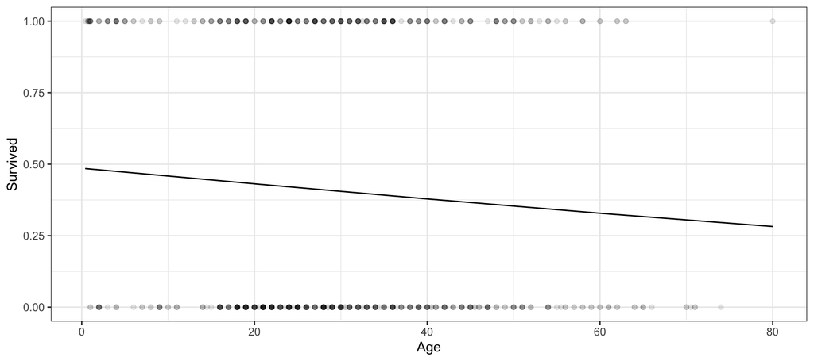

```r
## use 'effects' package to extract the fitted effect from a model:
mci <- as.data.frame(effect("Age",glm1))

ggplot(data=TitanicAll,aes(x=Age,y=Survived))+
  geom_point(alpha=.1)+
  geom_line(data=mci,aes(y=fit))+
  theme_bw()
```

# Contrasts and multiple predictors

We might want to ask a more complex question with the Titanic data, so we’ll turn back to thinking about contrasts. Setting contrasts becomes especially important when you have a model containing multiple predictors.

For more complex models, it matters what is 0 for *all factors*

That is to say:

A dummy coded model reflects the effect of factor A at the baseline level of factor B.

This is the case for all types of models– linear models, and logistic models. But in the Titanic data set it happens to be really easy to see!

Look at contrasts and interactions more with Titanic. We’ll subset the data to look at what happens by age and gender for first and second class passengers.

```r
## subset the data
TitanicSome <- TitanicAll %>% filter(Pclass != '3')
TitanicSome <- droplevels(TitanicSome)

TitanicSome$Pclass <- as.factor(TitanicSome$Pclass)
```

# Dummy contrasts and multiple predictors (in a glm)

Here is a model using *dummy* coding for both gender and passenger class. How to interpret it?

```r
## set dummy contrasts for both factors
contrasts(TitanicSome$Gender) <- c(0, 1)
contrasts(TitanicSome$Pclass) <- c(0, 1)

CsT1 <- contrasts(TitanicSome$Gender)
CpT1 <- contrasts(TitanicSome$Pclass)

T1 <- glm(Survived ~ Gender*Pclass, family='binomial',data=TitanicSome)

summary(T1)
```

```
##
## Call:
## glm(formula = Survived ~ Gender * Pclass, family = "binomial",
##     data = TitanicSome)
##
## Deviance Residuals:
##     Min       1Q   Median       3Q      Max
## -2.5861  -0.5732   0.2681   0.4112   1.9427
##
## Coefficients:
##                 Estimate Std. Error z value Pr(>|z|)
## (Intercept)       3.3081     0.5878   5.628 1.83e-08 ***
## Gender1          -3.7301     0.6220  -5.997 2.01e-09 ***
## Pclass1          -0.8804     0.7259  -1.213    0.225
## Gender1:Pclass1  -0.4204     0.8043  -0.523    0.601
## ---
## Signif. codes:  0 '***' 0.001 '**' 0.01 '*' 0.05 '.' 0.1 ' ' 1
##
## (Dispersion parameter for binomial family taken to be 1)
##
##     Null deviance: 490.41  on 358  degrees of freedom
## Residual deviance: 287.44  on 355  degrees of freedom
## AIC: 295.44
##
## Number of Fisher Scoring iterations: 6
```

# Effects contrasts and multiple predictors (in a glm)

Here is a model using *effects* coding for both gender and passenger class. How to interpret it?

```r
contrasts(TitanicSome$Gender) <- c(-.5,.5)
contrasts(TitanicSome$Pclass) <- c(-.5,.5)

CsT2 <- contrasts(TitanicSome$Gender)
CpT2 <- contrasts(TitanicSome$Pclass)


T2 <- glm(Survived ~ Gender*Pclass, family='binomial',data=TitanicSome)

summary(T2)
```

```
##
## Call:
## glm(formula = Survived ~ Gender * Pclass, family = "binomial",
##     data = TitanicSome)
##
## Deviance Residuals:
##     Min       1Q   Median       3Q      Max
## -2.5861  -0.5732   0.2681   0.4112   1.9427
##
## Coefficients:
##                 Estimate Std. Error z value Pr(>|z|)
## (Intercept)       0.8978     0.2011   4.465 8.01e-06 ***
## Gender1          -3.9403     0.4021  -9.798  < 2e-16 ***
## Pclass1          -1.0906     0.4021  -2.712  0.00669 **
## Gender1:Pclass1  -0.4204     0.8043  -0.523  0.60117
## ---
## Signif. codes:  0 '***' 0.001 '**' 0.01 '*' 0.05 '.' 0.1 ' ' 1
##
## (Dispersion parameter for binomial family taken to be 1)
##
##     Null deviance: 490.41  on 358  degrees of freedom
## Residual deviance: 287.44  on 355  degrees of freedom
## AIC: 295.44
##
## Number of Fisher Scoring iterations: 6
```

# Summary: contrasts and multiple predictors

Note the differences between the models…

- First, the good news: The interaction is identical in both models. The highest-order term (= interaction including all the factors in the model) is always identical no matter what the contrasts are. That’s because, again, it’s the same model.
- But, now the bad news: The effects terms are different.
- In model 1, it looks like there is an effect of gender but no effect of passenger class.
- In model 2, it looks like there is an effect of gender and passenger class.

```r
## dummy coded model
round(coef(summary(T1)),4)
```

```
##                 Estimate Std. Error z value Pr(>|z|)
## (Intercept)       3.3081     0.5878  5.6278   0.0000
## Gender1          -3.7301     0.6220 -5.9967   0.0000
## Pclass1          -0.8804     0.7259 -1.2128   0.2252
## Gender1:Pclass1  -0.4204     0.8043 -0.5227   0.6012
```

```r
## effects coded model
round(coef(summary(T2)),4)
```

```
##                 Estimate Std. Error z value Pr(>|z|)
## (Intercept)       0.8978     0.2011  4.4650   0.0000
## Gender1          -3.9403     0.4021 -9.7984   0.0000
## Pclass1          -1.0906     0.4021 -2.7119   0.0067
## Gender1:Pclass1  -0.4204     0.8043 -0.5227   0.6012
```

# Summary: contrasts and multiple predictors

What is actually going on is that there is no *simple effect* of passenger class in gender=Female, but there is a *main effect* of passenger class (First class people survived more often).

```r
round(coef(summary(T1)),4)
```

```
##                 Estimate Std. Error z value Pr(>|z|)
## (Intercept)       3.3081     0.5878  5.6278   0.0000
## Gender1          -3.7301     0.6220 -5.9967   0.0000
## Pclass1          -0.8804     0.7259 -1.2128   0.2252
## Gender1:Pclass1  -0.4204     0.8043 -0.5227   0.6012
```

```r
round(coef(summary(T2)),4)
```

```
##                 Estimate Std. Error z value Pr(>|z|)
## (Intercept)       0.8978     0.2011  4.4650   0.0000
## Gender1          -3.9403     0.4021 -9.7984   0.0000
## Pclass1          -1.0906     0.4021 -2.7119   0.0067
## Gender1:Pclass1  -0.4204     0.8043 -0.5227   0.6012
```

This becomes easier to see in a plot:

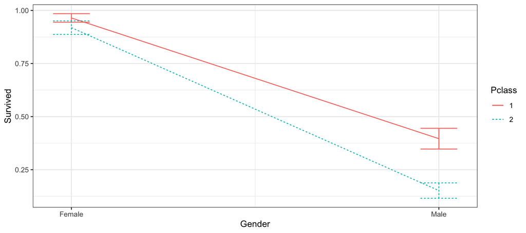

```r
ggplot(TitanicSome,aes(x=as.numeric(Gender), y=Survived, color=Pclass, lty=Pclass))+
    stat_summary(fun.y = mean, geom = "line") +
    stat_summary(fun.data = mean_se, geom = "errorbar",width=.1)+
    theme_bw()+
    scale_x_continuous("Gender",breaks=c(1,2),labels=c("Female","Male"))
```

# Recap

Regressions are a great way of capturing the a relationship between values that can be described as a line:

- for linear outcomes with linear predictors
- for binomial outcomes with linear predictors (by looking at log odds)
- and for linear/binomial outcomes with categorical predictors (by setting contrasts, aka X values)

In the output of a regression model you get:

- An intercept– what is Y when X=0 ? This estimate might reliably differ from zero, according to the t-value associated with it– and in your analysis, you might or might not care whether it does.
- Slopes for each fixed effect predictor of interest– how much does the value of Y change when X changes by one unit? You probaably care about the size of this effect (the size of the t-value)

# Extra time:

1. Questions?
2. Play with some data– implement a fixed-effects only lm or glm for lexdec or Titanic.